# Chapter 10

## Q11

*On the book website, www.StatLearning.com, there is a gene expression data set (Ch10Ex11.csv) that consists of 40 tissue samples with measurements on 1,000 genes. The first 20 samples are from healthy patients, while the second 20 are from a diseased group.*

*(a) Load in the data using read.csv(). You will need to select header=F.*

```r
con <- curl::curl("http://www-bcf.usc.edu/~gareth/ISL/Ch10Ex11.csv")
data.exp <- read_csv(con,col_names = FALSE)
head(data.exp)
```

```
## # A tibble: 6 x 40
##            X1         X2         X3         X4         X5         X6
##         <dbl>      <dbl>      <dbl>      <dbl>      <dbl>      <dbl>
## 1 -0.96193340  0.4418028 -0.9750051  1.4175040  0.8188148  0.3162937
## 2 -0.29252570 -1.1392670  0.1958370 -1.2811210 -0.2514393  2.5119970
## 3  0.25878820 -0.9728448  0.5884858 -0.8002581 -1.8203980 -2.0589240
## 4 -1.15213200 -2.2131680 -0.8615249  0.6309253  0.9517719 -1.1657240
## 5  0.19578280  0.5933059  0.2829921  0.2471472  1.9786680 -0.8710180
## 6  0.03012394 -0.6910143 -0.4034258 -0.7298590 -0.3640986  1.1253490
## # ... with 34 more variables: X7 <dbl>, X8 <dbl>, X9 <dbl>, X10 <dbl>,
## #   X11 <dbl>, X12 <dbl>, X13 <dbl>, X14 <dbl>, X15 <dbl>, X16 <dbl>,
## #   X17 <dbl>, X18 <dbl>, X19 <dbl>, X20 <dbl>, X21 <dbl>, X22 <dbl>,
## #   X23 <dbl>, X24 <dbl>, X25 <dbl>, X26 <dbl>, X27 <dbl>, X28 <dbl>,
## #   X29 <dbl>, X30 <dbl>, X31 <dbl>, X32 <dbl>, X33 <dbl>, X34 <dbl>,
## #   X35 <dbl>, X36 <dbl>, X37 <dbl>, X38 <dbl>, X39 <dbl>, X40 <dbl>
```

*(b) Apply hierarchical clustering to the samples using correlation- based distance, and plot the dendrogram. Do the genes separate the samples into the two groups? Do your results depend on the type of linkage used?*

```r
dd <- as.dist(1-cor(data.exp))
hc.complete <- hclust(dd,method="complete")
hc.single <- hclust(dd,method="single")
hc.average <- hclust(dd,method="average")
```

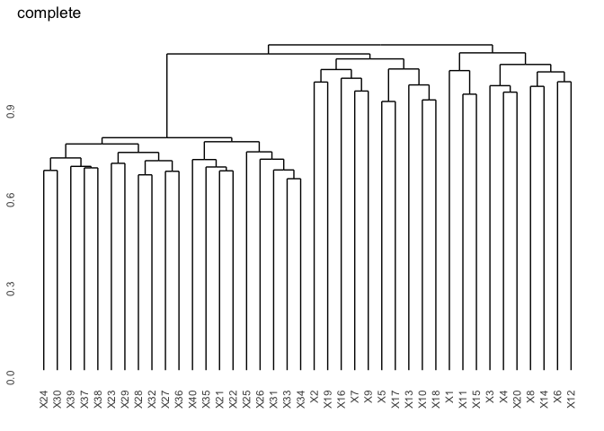

```r
ggdendrogram(hc.complete) + ggtitle("complete")
```

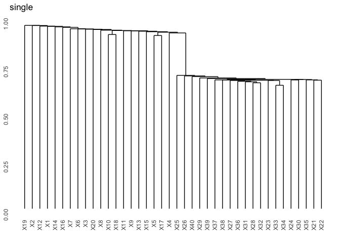

```r
ggdendrogram(hc.single) + ggtitle("single")
```

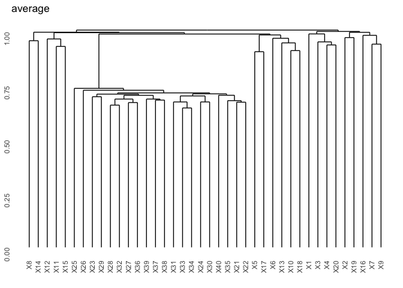

```r
ggdendrogram(hc.average) + ggtitle("average")
```

3. Your collaborator wants to know which genes differ the most across the two groups. Suggest a way to answer this question, and apply it here.

Could do PCA and look at the loadings of the PC that separates the groups…

Or binomial lasso

```r
library(glmnet)
```

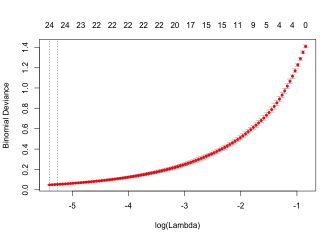

```r
cvglm11 <- cv.glmnet(x=t(data.exp),y=rep(c(0,1),each=20),alpha=1,family="binomial")

plot(cvglm11)
```

```r
cvglm11$lambda.1se
```

```
## [1] 0.005169919
```

```r
glmnet11 <- glmnet(x=t(data.exp),y=rep(c(0,1),each=20),alpha=1, lambda=cvglm11$lambda.1se, family="binomial")

sort(glmnet11$beta[glmnet11$beta[,1] > 0,],decreasing = TRUE)
```

```
##        V600        V589        V565        V588        V570        V538
## 0.723033492 0.580628833 0.446321091 0.369333913 0.295406333 0.242075867
##        V502        V505        V583        V561        V584        V599
## 0.228681448 0.202033272 0.189590955 0.166890560 0.141928629 0.132575677
##         V11        V574        V569        V503        V590        V522
## 0.130907520 0.113004483 0.101358078 0.069604610 0.048523567 0.037126707
##         V13        V508        V582        V516        V554
## 0.030323840 0.015595826 0.013689514 0.010348587 0.004372943
```